# Tugas 5 MPDW

Delia Fitri Audina

## Package

```r
library(ggplot2)
library(tsibble)
library(tseries)
library(MASS)
library(readxl)
library(dplyr)
library(forecast)
library(moments)
```

## Input Data

```r
data <- read_xlsx("C:/Users/Delia/OneDrive/Documents/MPDW 5/Data Tugas5.xlsx")
data
```

```
## # A tibble: 100 × 2
##    Periode             Kendaraan
##    <dttm>                  <dbl>
##  1 2024-02-08 00:00:00     58790
##  2 2024-02-09 00:00:00     31121
##  3 2024-02-10 00:00:00     29444
##  4 2024-02-11 00:00:00     24777
##  5 2024-02-12 00:00:00     24370
##  6 2024-02-13 00:00:00     27939
##  7 2024-02-14 00:00:00     19336
##  8 2024-02-15 00:00:00     23742
##  9 2024-02-16 00:00:00     29353
## 10 2024-02-17 00:00:00     30447
## # ℹ 90 more rows
```

# Seluruh Data

```r
data$Kendaraan <- ts(data$Kendaraan)
data$Periode <- as.Date(data$Periode)
data
```

```
## # A tibble: 100 × 2
##    Periode    Kendaraan
##    <date>         <dbl>
##  1 2024-02-08     58790
##  2 2024-02-09     31121
##  3 2024-02-10     29444
##  4 2024-02-11     24777
##  5 2024-02-12     24370
##  6 2024-02-13     27939
##  7 2024-02-14     19336
##  8 2024-02-15     23742
##  9 2024-02-16     29353
## 10 2024-02-17     30447
## # ℹ 90 more rows
```

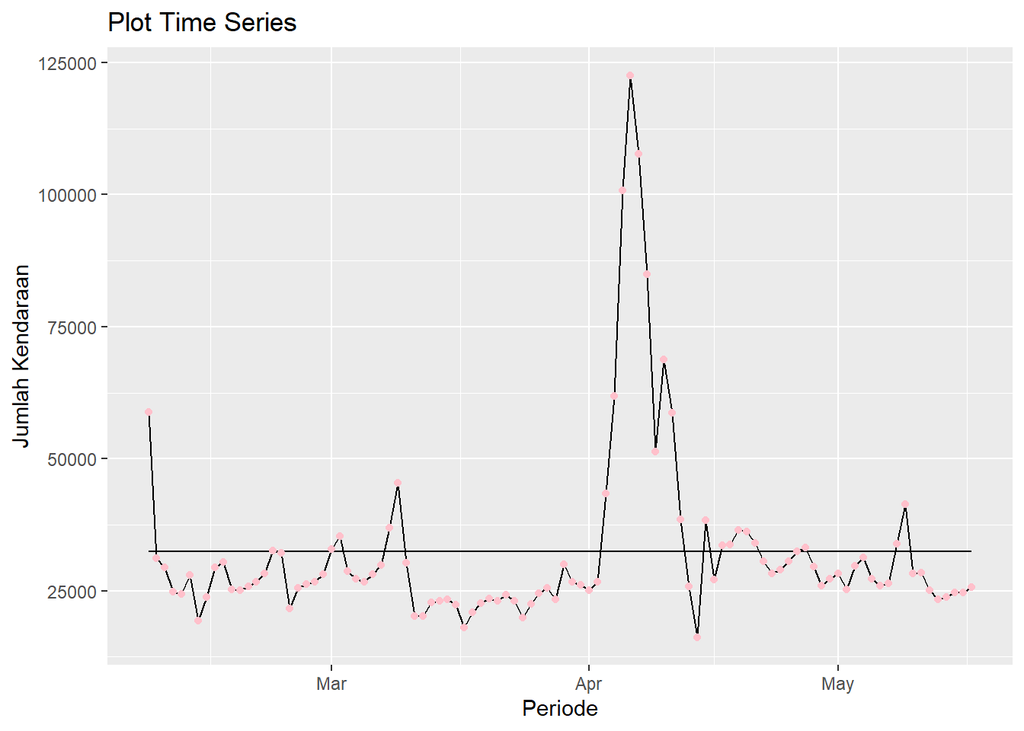

```r
# Plot time series
ggplot(data, aes(x = Periode, y = Kendaraan)) +
  geom_line(y = mean(data$Kendaraan, color = "yellow"))+
  geom_line(color = "black") +
  geom_point(color = "pink") +
  labs(title = "Plot Time Series", x = "Periode", y = "Jumlah Kendaraan")
```

Menurut plot time series, jumlah Kendaraan pada tol terlihat tidak stasioner baik dari segi rataan maupun ragam. Terdapat komponen musiman dengan fluktuasi signifikan di beberapa titik waktu, serta beberapa lonjakan yang perlu dieksplorasi lebih lanjut. Sehingga perlu beberapa pengujian.

### Plot ACF

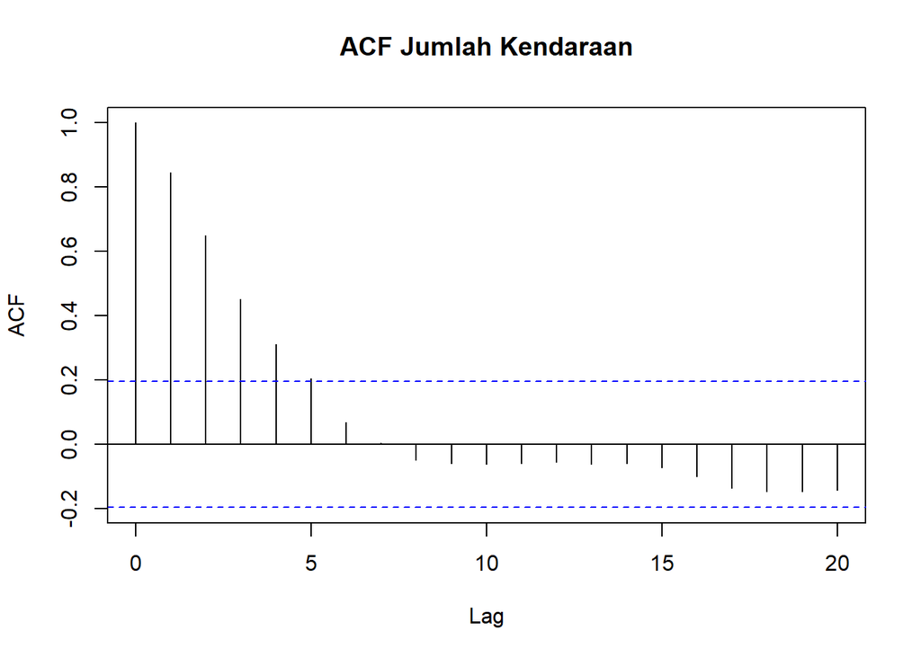

```r
acf(data$Kendaraan, main="ACF Jumlah Kendaraan")
```

Berdasarkan plot ACF, pada data tersebut cenderung *tails off* yang konsisten dengan karakteristik model autoregressive (AR). Data menunjukkan adanya autokorelasi yang signifikan di beberapa lag awal, namun perlahan menurun. Ini mengindikasikan bahwa data masih memiliki hubungan antarwaktu yang signifikan dan mungkin membutuhkan pemrosesan lebih lanjut untuk mencapai stasioneritas.

### Plot PACF

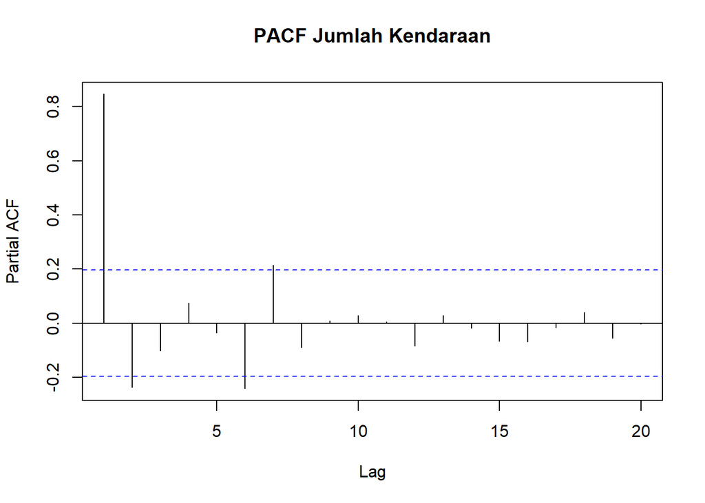

```r
pacf(data$Kendaraan, main="PACF Jumlah Kendaraan")
```

### Uji ADF

```r
tseries::adf.test(data$Kendaraan)
```

```
##
##  Augmented Dickey-Fuller Test
##
## data:  data$Kendaraan
## Dickey-Fuller = -2.9555, Lag order = 4, p-value = 0.1808
## alternative hypothesis: stationary
```

$H_0$ : Data tidak stasioner dalam rataan

$H_1$ : Data stasioner dalam rataan

Berdasarkan uji ADF tersebut, didapat *p-value* sebesar 0.1808 yang lebih besar dari taraf nyata 5% sehingga tak cukup bukti untuk menolak $H_0$ dan menandakan bahwa data tidak stasioner dalam rataan.

### Uji Box-Cox

```r
n <- nrow(data)
index <- seq(1:n)
bc = boxcox(data$Kendaraan~index)
```

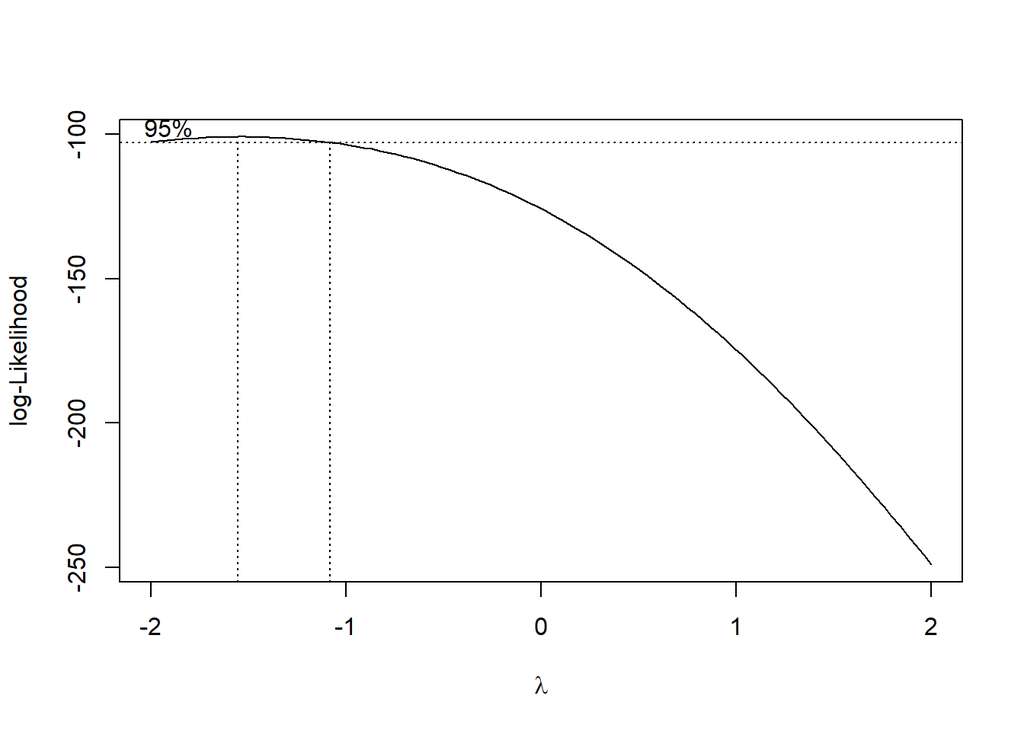

```r
#Nilai Rounded Lambda
lambda <- bc$x[which.max(bc$y)]
lambda
```

```
## [1] -1.555556
```

```r
#SK
bc$x[bc$y > max(bc$y) - 1/2 * qchisq(.95,1)]
```

```
##  [1] -2.000000 -1.959596 -1.919192 -1.878788 -1.838384 -1.797980 -1.757576
##  [8] -1.717172 -1.676768 -1.636364 -1.595960 -1.555556 -1.515152 -1.474747
## [15] -1.434343 -1.393939 -1.353535 -1.313131 -1.272727 -1.232323 -1.191919
## [22] -1.151515 -1.111111
```

Gambar di atas menunjukkan nilai *rounded value* ($\lambda$) optimum sebesar **-1.56** dan pada selang kepercayaan 95% nilai memiliki batas bawah **-2.0** dan batas atas **-1.11**. Selang tersebut tidak memuat nilai satu sehingga dapat dikatakan bahwa data tidak stasioner dalam ragam.

# Partisi Data

## Bagian 1

```r
data1 <- data[1:50,]
data1$Saham <- ts(data1$Kendaraan)
data1$Periode <- as.Date(data1$Periode)
```

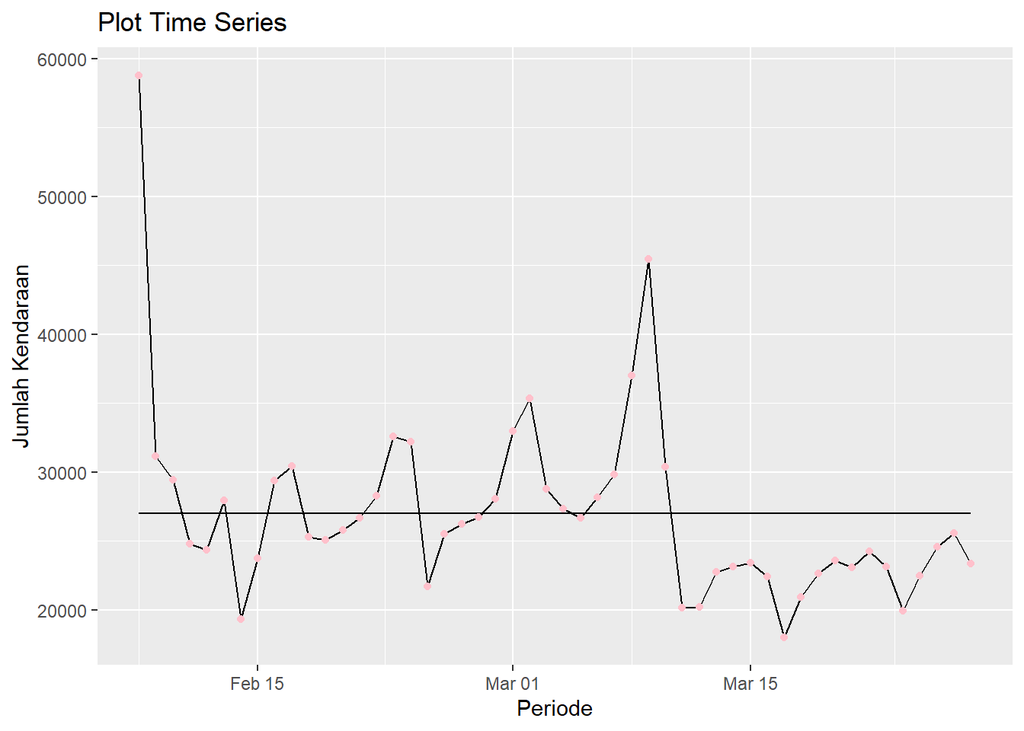

```r
# Plot time series
ggplot(data1, aes(x = Periode, y = Kendaraan)) +
  geom_line(y = mean(data1$Kendaraan, color = "yellow"))+
  geom_line(color = "black") +
  geom_point(color = "pink") +
  labs(title = "Plot Time Series", x = "Periode", y = "Jumlah Kendaraan")
```

### Plot ACF

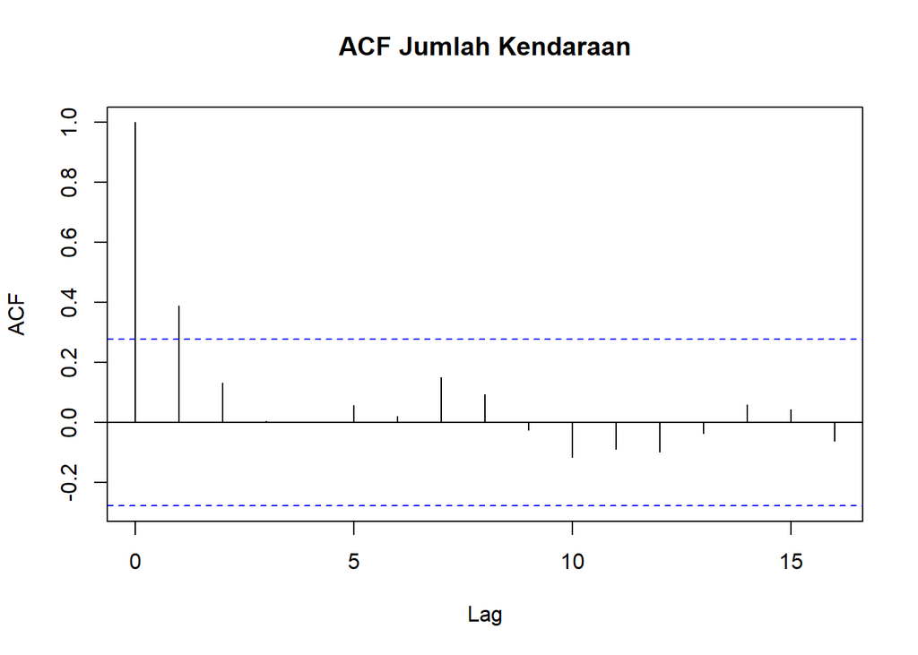

```r
acf(data1$Kendaraan, main="ACF Jumlah Kendaraan")
```

Berdasarkan plot ACF, terlihat bahwa plot ACF pada data tersebut cenderung *tails off*

### Plot PACF

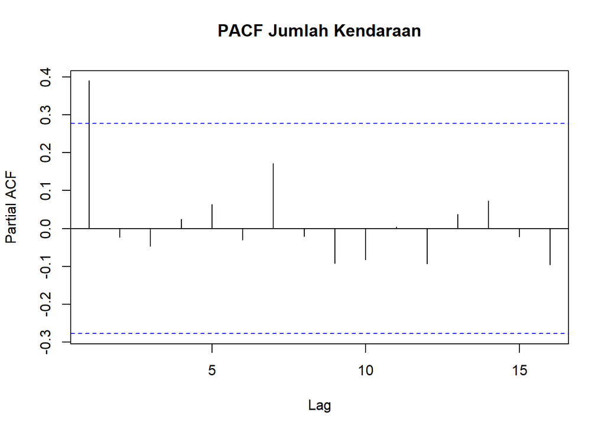

```r
pacf(data1$Kendaraan, main="PACF Jumlah Kendaraan")
```

Data bersifat cuts-off setelah lag ke-1 di PACF. Data 1 jumlah kendaraan diduga berbentuk AR(1)

### Uji ADF

```r
adf.test(data1$Kendaraan)
```

```
##
##  Augmented Dickey-Fuller Test
##
## data:  data1$Kendaraan
## Dickey-Fuller = -3.0051, Lag order = 3, p-value = 0.1711
## alternative hypothesis: stationary
```

$H_0$ : Data tidak stasioner dalam rataan

$H_1$ : Data stasioner dalam rataan

Berdasarkan uji ADF tersebut, didapat *p-value* sebesar 0.1711 yang lebih besar dari taraf nyata 5% sehingga tak cukup bukti untuk menolak $H_0$ dan menandakan bahwa data tidak stasioner dalam rataan.

### Uji Box-Cox

```r
n <- nrow(data1)
index <- seq(1:n)
bc = boxcox(data1$Kendaraan~index)
```

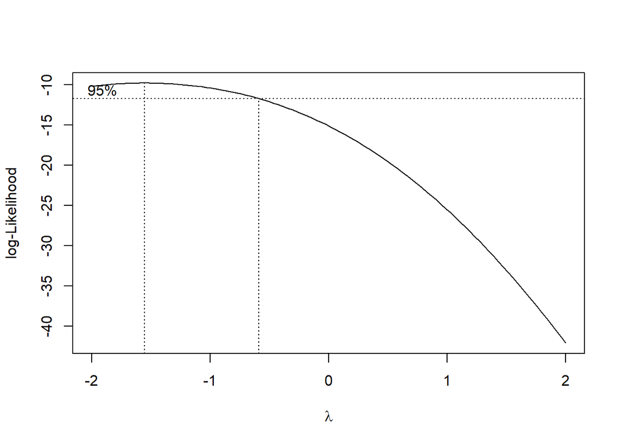

```r
#Nilai Rounded Lambda
lambda <- bc$x[which.max(bc$y)]
lambda
```

```
## [1] -1.555556
```

```r
#SK
bc$x[bc$y > max(bc$y) - 1/2 * qchisq(.95,1)]
```

```
##  [1] -2.0000000 -1.9595960 -1.9191919 -1.8787879 -1.8383838 -1.7979798
##  [7] -1.7575758 -1.7171717 -1.6767677 -1.6363636 -1.5959596 -1.5555556
## [13] -1.5151515 -1.4747475 -1.4343434 -1.3939394 -1.3535354 -1.3131313
## [19] -1.2727273 -1.2323232 -1.1919192 -1.1515152 -1.1111111 -1.0707071
## [25] -1.0303030 -0.9898990 -0.9494949 -0.9090909 -0.8686869 -0.8282828
## [31] -0.7878788 -0.7474747 -0.7070707 -0.6666667 -0.6262626
```

## Bagian 2

```r
data2 <- data[50:100,]
data2$Kendaraan <- ts(data2$Kendaraan)
data2$Periode <- as.Date(data2$Periode)
```

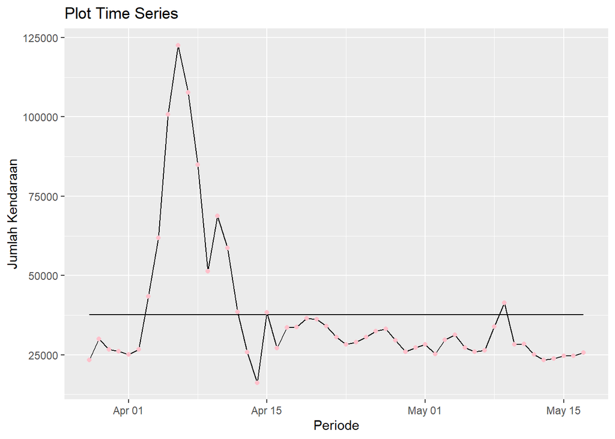

```r
# Plot time series
ggplot(data2, aes(x = Periode, y = Kendaraan)) +
  geom_line(y = mean(data2$Kendaraan, color = "yellow"))+
  geom_line(color = "black") +
  geom_point(color = "pink") +
  labs(title = "Plot Time Series", x = "Periode", y = "Jumlah Kendaraan")
```

### Plot ACF

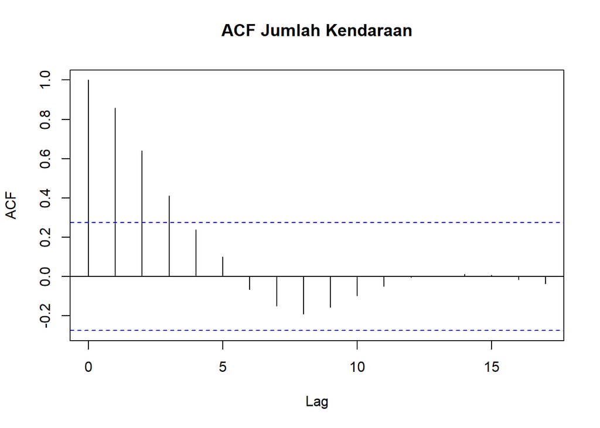

```r
acf(data2$Kendaraan, main="ACF Jumlah Kendaraan")
```

Berdasarkan plot ACF, terlihat bahwa plot ACF pada data tersebut cenderung *tails off*

### Plot PACF

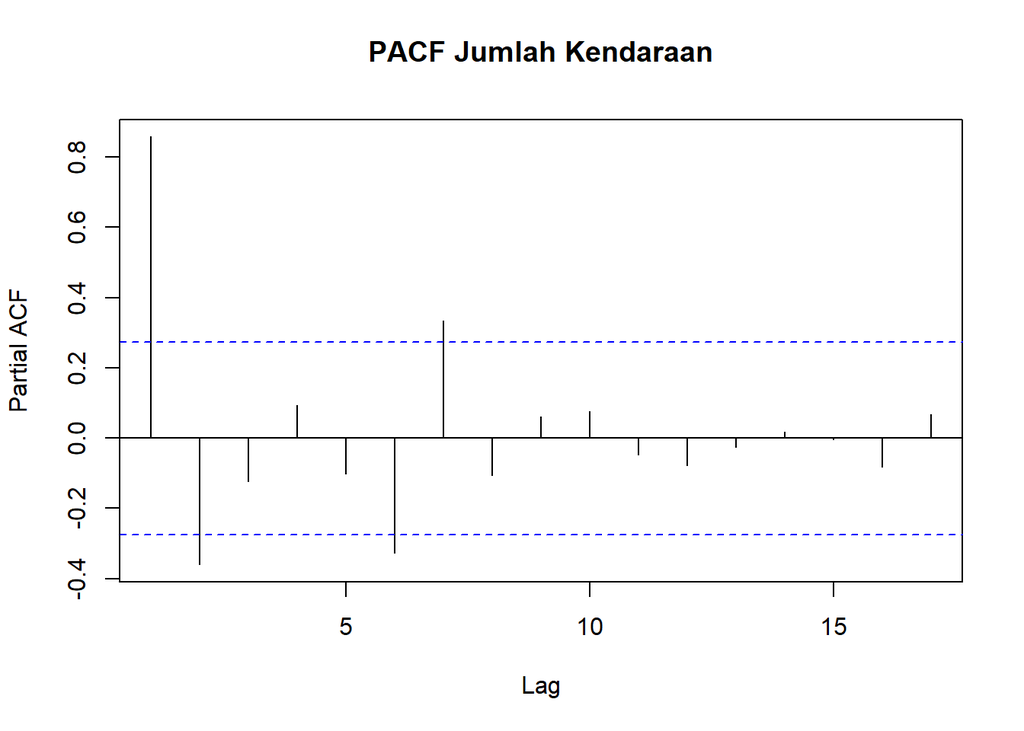

```r
pacf(data2$Kendaraan, main="PACF Jumlah Kendaraan")
```

### Uji ADF

```r
adf.test(data2$Kendaraan)
```

```
##
##  Augmented Dickey-Fuller Test
##
## data:  data2$Kendaraan
## Dickey-Fuller = -3.0912, Lag order = 3, p-value = 0.1357
## alternative hypothesis: stationary
```

$H_0$ : Data tidak stasioner dalam rataan

$H_1$ : Data stasioner dalam rataan

Berdasarkan uji ADF tersebut, didapat *p-value* sebesar 0.1357 yang lebih besar dari taraf nyata 5% sehingga tak cukup bukti untuk menolak $H_0$ dan menandakan bahwa data tidak stasioner dalam rataan.

### Uji Box-Cox

```r
n <- nrow(data2)
index <- seq(1:n)
bc = boxcox(data2$Kendaraan~index)
```

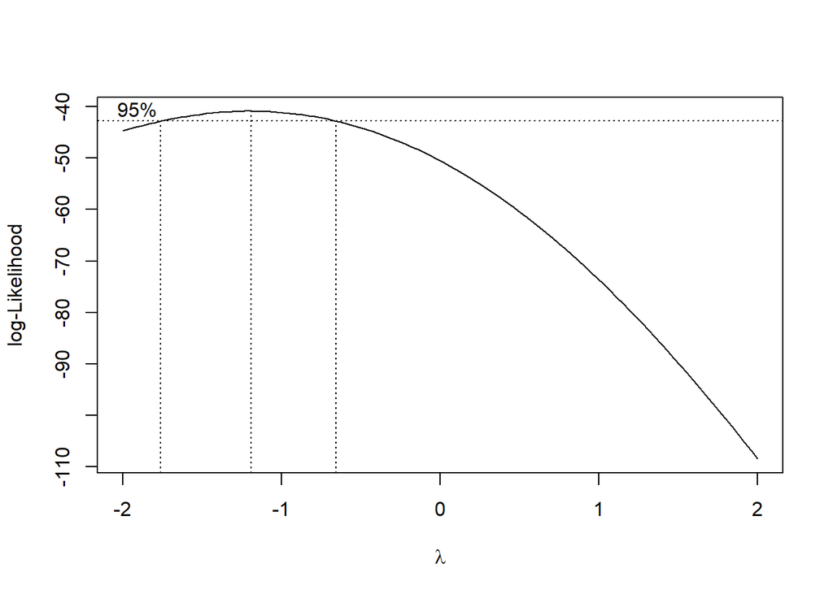

```r
#Nilai Rounded Lambda
lambda <- bc$x[which.max(bc$y)]
lambda
```

```
## [1] -1.191919
```

```r
#SK
bc$x[bc$y > max(bc$y) - 1/2 * qchisq(.95,1)]
```

```
##  [1] -1.7575758 -1.7171717 -1.6767677 -1.6363636 -1.5959596 -1.5555556
##  [7] -1.5151515 -1.4747475 -1.4343434 -1.3939394 -1.3535354 -1.3131313
## [13] -1.2727273 -1.2323232 -1.1919192 -1.1515152 -1.1111111 -1.0707071
## [19] -1.0303030 -0.9898990 -0.9494949 -0.9090909 -0.8686869 -0.8282828
## [25] -0.7878788 -0.7474747 -0.7070707 -0.6666667
```

Gambar di atas menunjukkan nilai *rounded value* ($\lambda$) optimum sebesar **-1.19** dan pada selang kepercayaan 95% nilai memiliki batas bawah **-1.75** dan batas atas **-0.67**. Selang tersebut tidak memuat nilai satu sehingga dapat dikatakan bahwa data tidak stasioner dalam ragam.

# Kesimpulan

1. Seluruh data dihasilkan bahwa data tidak stasioner dalam rataan maupun ragam
2. Partisi data bagian 1 dihasilkan bahwa data tidak stasioner dalam rataan maupun ragam
3. Partisi data bagian 2 dihasilkan bahwa data tidak stasioner dalam rataan maupun ragam

Dari Beberapa uji yang telah dilakukan, Seluruh Data, Partisi Data bagian 1 dan 2 didapatkan hasil bahwa data tidak stasioner dalam rataan maupun ragam